# Choosing a dataset

In this tutorial we use one of the datasets available from the NCBI GEO database. You are encouraged to follow along with the tutorial using the Grady Trauma Project, and once you’ve gotten some experience following along, then practice with another dataset. The NCBI GEO database can be a bit tricky to navigate, so for ease, I’ve curated a catalog of 70 Illumina MethylationEPIC GEO Series (including the dataset used in the tutorial) that carry enough phenotype and covariate metadata to support a real association analysis. Browse it to understand the landscape of public EPIC data and to pick your own dataset for a project.

The full table is downloadable as a CSV at the bottom of the page so you can filter and load it in R or Python yourself.

## The catalog

Each row is one study. A few were deposited under several GEO accessions — a SuperSeries alongside its SubSeries — and those appear as a single row with every accession listed, so the 70 Series below collapse to 60 studies. The table is searchable and sortable — click a column header to sort, or type in the box to filter (e.g. type `Strong` to see only the top-tier studies, or a gene/phenotype term to find studies on a topic). The Grady Trauma Project (GSE132203) the dataset used throughout this tutorial, is highlighted.

| GEO accession | Title | Phenotypes | Suitability tier | Suitability score | Methylation array | N samples | Has sex | Has age | Has ancestry | Has genetic PCs | Has cell composition | N phenotypes | PubMed |
| --- | --- | --- | --- | --- | --- | --- | --- | --- | --- | --- | --- | --- | --- |
| GSE158063, GSE158064 | Smaller stature in childhood following assisted reproductive technologies (ART) is not explained by parental or gestational factors, early childhood environment, or fetal DNA methylation [GUSTO_buffy_… | art treatment status, pre-pregnancy bmi (kg/m^2) | Strong | 7 | EPIC (850K) | 915 | True | True | True | False | False | 2 | 34556649 |
| GSE224365, GSE224363, GSE224364 | Epigenetic analysis of psychosocial stress among mother-newborn dyads in the Democratic Republic of Congo | birthweight, delivery mode, maternal alcohol, parity, general trauma, sexual trauma, war trauma, chronic stress, cohort | Strong | 7 | EPIC (850K) | 712 | True | True | False | False | False | 9 | 37300821 |
| GSE179325 | COVID-19 DNA methylation analysis | subject status, cohort, disease state | Strong | 7 | EPIC (850K) | 574 | True | True | False | False | False | 3 | 35933486 |
| GSE219037 | Methylation data to study immune response to SARS-CoV-2 virus infection in COVID-19 Health Action Response for Marines (CHARM) study | sample collection time point (days since t0), group | Strong | 7 | EPIC (850K) | 553 | True | True | True | False | False | 2 | 36919946 |
| GSE175458, GSE175459 | Functional Validation of Common Idiopathic Pulmonary Fibrosis Genetic Risk Variants [850k methylation arrays] | dx, case_control_status, smoking_ever_never | Strong | 7 | EPIC (850K) | 547 | True | True | True | False | False | 3 | 35816432 |
| GSE217633 | Effect of HIV infection and antiretroviral therapy initiation on genome-wide DNA methylation patterns. | treatment, week, hiv_rna, years_hiv, time | Strong | 7 | EPIC (850K) | 413 | True | True | False | False | False | 5 | 36640455 |
| GSE167885 | Dataset for Placental Genomic and Epigenomic Signatures in Infants Borns at Extremely Low Gestational Age [DNA methylation] | birthweight (grams), bmi (body mass index) | Strong | 7 | EPIC (850K) | 411 | True | True | False | False | False | 2 | 35121757 |
| GSE168739 | Epigenome-Wide Association Study of COVID-19 Severity with Respiratory Failure | disease state | Strong | 7 | EPIC (850K) | 407 | True | True | False | False | False | 1 | 33867313 |
| GSE132181 | Genome wide blood DNA methylation measured at birth and age 7 on the EPIC array | gestationalage_birth, samplecollectionsite | Strong | 7 | EPIC (850K) | 392 | True | True | True | True | True | 2 |  |
| GSE284764 | Epigenome-Wide Association Study of the Interaction between Alzheimer’s disease and Systemic Infection | post-mortem delay, braak stage, ad diagnosis | Strong | 7 | EPIC (850K) | 242 | True | True | False | False | True | 3 | 40166175 |

[output cut: 50 more lines]

## What the columns mean

| Column | Meaning |
| --- | --- |
| `GEO accession` | GEO Series accession — the identifier you give to `getGEO()` or use in the FTP path to download IDATs. Where a study was deposited as a SuperSeries plus SubSeries, every accession is listed here and t… |
| `Title` | The study’s deposited title. |
| `Suitability tier` / `Suitability score` | Our teaching-suitability grade (**Strong / Moderate / Limited**) and the underlying score, based on metadata completeness (sex, age, phenotype, raw data). Higher is better for a first EWAS. |
| `Methylation array` | Array generation(s) present. Most are EPIC v1 (850K); a few mix in 450K or EPIC v2, which matters because probe IDs differ across generations. |
| `N samples` | Total samples across all matrix files for the first accession listed (super-series are summed). |
| `Has sex`, `Has age` | Whether sex and age are in the sample characteristics — both are strong methylation covariates you will almost always model. |
| `Has ancestry` | Whether genetic ancestry / race is reported (relevant for ancestry-aware probe masking, as in Probe filtering). |
| `Has genetic PCs` | Whether genetic ancestry principal components are deposited with the samples, for use as model covariates (see Genetic ancestry PCs). |
| `Has cell composition` | Whether cell-type proportions are deposited — not necessary, but saves a step in data pre-processing if it is available. |
| `Phenotypes`, `N phenotypes` | The variables you could actually test — every phenotype and exposure field the submitter deposited, named but without their values. A cell reading *none deposited* means exactly that: the study’s char… |
| `PubMed` | Linked publication, where one exists. |

**TipWhat makes a good *first* EWAS dataset**

Sort by `Suitability_tier`, then look for: **raw IDATs deposited** (so you can start from raw data), **both age and sex present**, at least one **genuine phenotype** you find interesting, and ideally **whole blood or PBMC** so you get to practice cell-type deconvolution. Deposited cell proportions values are a bonus — they give you an answer key to check your own pipeline against, or you can skip this step and just use the deposited cell proportions.

## How the catalog was assembled

The 70 Series are the result of a deliberate screen:

Metadata was then read directly from the **Series Matrix file header** (`GSE*_series_matrix.txt.gz`) — source name, `characteristics` tag–value pairs, platform, and sample count. This is a quick and easy way to profile GEO studies without committing to downloading all the data.

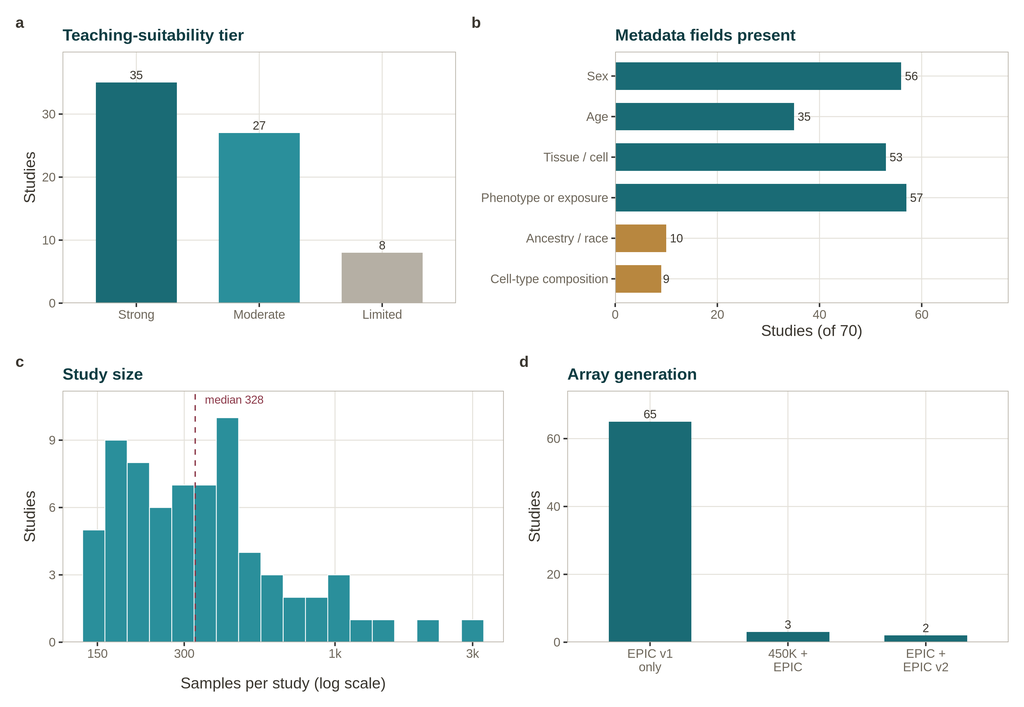

## The tutorial dataset

From the shortlist we chose **GSE132203**, the Grady Trauma Project, because it is unusually complete for teaching: raw IDATs are deposited, it has explicit age and sex plus several trauma/PTSD exposures, and it provides cell-type proportions, giving us answer keys to validate the deconvolution step against. There are also published manuscripts that we can compare our results with (Smith et al. 2011) (Katrinli et al. 2024).

**NoteNot every study gives you IDATs**

Some GEO methylation studies deposit only a processed beta-value matrix, not raw IDATs. You can still use these for your rotation — the Normalization notebook includes notes on how to enter the workflow from a processed matrix and which steps you can and cannot still do.

## Download the catalog

The catalog is available as a CSV. It holds exactly the 60 studies in the table above, in the same order, with 31 columns rather than the 14 shown:

- **methylation_geo_catalog.csv** — ready to load with `read_csv()` (R) or `pd.read_csv()` (Python).

`GSE` and `N_samples` are comma-separated and aligned with each other, so the Congo study reads `GSE224365, GSE224363, GSE224364` against `712, 356, 356`. Every other column describes the **first** accession listed. The file is written by the same chunk that draws the table, so the download cannot drift from what you see above.

You can also grab the current view directly from the table using the **CSV** and **Copy** buttons above it.

**Next:** with a dataset in hand, head to Background to meet the platform — or, if you already know the array, skip straight to Setup to download the raw IDATs and read them into R.

## References

Katrinli, Seyma et al. 2024. “Epigenome-Wide Association Studies Identify Novel DNA Methylation Sites Associated with PTSD: A Meta-Analysis of 23 Military and Civilian Cohorts.” *Genome Medicine* 16: 147. https://doi.org/10.1186/s13073-024-01417-1.

Smith, Alicia K, Karen N Conneely, Varun Kilaru, et al. 2011. “Differential Immune System DNA Methylation and Cytokine Regulation in Post-Traumatic Stress Disorder.” *American Journal of Medical Genetics Part B* 156 (6): 700–708. https://doi.org/10.1002/ajmg.b.31212.